# R Notebook

```r
library(prob)
library(gtools)
library(tidyverse)
library(janitor)
```

```r
titanic <- read_csv("data/titanic.csv")
```

```r
class_count <- titanic %>%
  group_by(class) %>%
  summarise(n())

class_count
```

| class | n() |
| --- | --- |
| 1st | 324 |
| 2nd | 284 |
| 3rd | 709 |
| deck crew | 66 |
| engineering crew | 324 |
| restaurant staff | 69 |
| victualling crew | 431 |

```r
titanic <- titanic %>%
  mutate(
    crew = case_when(
      str_detect(class, "crew") ~ TRUE,
      str_detect(class, "staff") ~ TRUE,
      TRUE ~ FALSE
    ),
    .after = age
  )
```

```r
# Produces a 2 x 2 table
class_table <- titanic %>%
  tabyl(class, survived)

class_table
```

```
            class  no yes
              1st 123 201
              2nd 166 118
              3rd 528 181
        deck crew  23  43
 engineering crew 253  71
 restaurant staff  66   3
 victualling crew 337  94
```

```r
class_table <- class_table %>%
  adorn_totals(where = c("row", "col"))

class_table
```

```
            class   no yes Total
              1st  123 201   324
              2nd  166 118   284
              3rd  528 181   709
        deck crew   23  43    66
 engineering crew  253  71   324
 restaurant staff   66   3    69
 victualling crew  337  94   431
            Total 1496 711  2207
```

```r
class_table_percent <- class_table %>%
  adorn_percentages() %>%
  adorn_title()

class_table_percent
```

```
                           survived
            class                no                yes Total
              1st  0.37962962962963   0.62037037037037     1
              2nd 0.584507042253521  0.415492957746479     1
              3rd 0.744710860366714  0.255289139633286     1
        deck crew 0.348484848484849  0.651515151515151     1
 engineering crew 0.780864197530864  0.219135802469136     1
 restaurant staff 0.956521739130435 0.0434782608695652     1
 victualling crew 0.781902552204176  0.218097447795824     1
            Total 0.677843226098777  0.322156773901223     1
```

## Question

Calculate the conditional probabilities prob(survived∣crew) and prob(survived∣passenger) to settle this dispute.

Have a look at the distinct values of the class variable, this will tell you whether each individual was a passenger (1st, 2nd or 3rd class) or a member of the crew (treat restaurant staff as crew)

## Further Analysis

prob(survived|Crew) -> probability of surviving given that a person is part of the crew prob(survived∣passenger)-> probability of surviving given that a person is a passenger

Calculate the conditional probabilities of: prob(survived|1st class | passenger) prob(survived|2nd class | passenger) prob(survived|3rd class | passenger)

```r
# probability that person is a 1st class passenger
first_class <- titanic %>%
  summarise(prob = sum(class == "1st") / n())
first_class
```

| prob |
| --- |
| 0.1468056 |

```r
# probability that person is a 2nd class passenger
second_class <- titanic %>%
  summarise(prob = sum(class == "2nd") / n())
second_class
```

| prob |
| --- |
| 0.1286815 |

```r
# probability that person is a 3rd class passenger
third_class <- titanic %>%
  summarise(prob = sum(class == "3rd") / n())
third_class
```

| prob |
| --- |
| 0.3212506 |

```r
# probability that person is a passenger
prob_passenger <- titanic %>%
  summarise(prob = sum(crew == FALSE) / n())
prob_passenger
```

| prob |
| --- |
| 0.5967377 |

```r
# probability that person survived
prob_survived <- titanic %>%
  summarise(prob = sum(survived == "yes") / n())
prob_survived
```

| prob |
| --- |
| 0.3221568 |

```r
# probability 1st class and survived
prob_survived_1st_class <- titanic %>%
    filter(survived == "yes", class == "1st") %>%
    summarise(prob = n()/ nrow(titanic))
prob_survived_1st_class
```

| prob |
| --- |
| 0.09107386 |

```r
# probability 2nd class and survived
prob_survived_2nd_class <- titanic %>%
    filter(survived == "yes", class == "2nd") %>%
    summarise(prob = n()/ nrow(titanic))
prob_survived_2nd_class
```

| prob |
| --- |
| 0.05346624 |

```r
# probability 3rd class and survived
prob_survived_3rd_class <- titanic %>%
    filter(survived == "yes", class == "3rd") %>%
    summarise(prob = n()/ nrow(titanic))
prob_survived_3rd_class
```

| prob |
| --- |
| 0.08201178 |

```r
# probability passenger and survived
prob_survived_passenger <- titanic %>%
    filter(survived == "yes", crew == FALSE) %>%
    summarise(prob = n()/ nrow(titanic))
prob_survived_passenger
```

| prob |
| --- |
| 0.2265519 |

```r
prob_survived_given_passenger <-
      prob_survived_passenger / prob_passenger

prob_survived_given_passenger
```

| prob |
| --- |
| 0.3796507 |

```r
NA
```

```r
prob_survived_given_1st_class <-
      prob_survived_1st_class / first_class

prob_survived_given_1st_class
```

| prob |
| --- |
| 0.6203704 |

```r
NA
```

```r
prob_survived_given_2nd_class <-
      prob_survived_2nd_class / second_class

prob_survived_given_2nd_class
```

| prob |
| --- |
| 0.415493 |

```r
NA
```

```r
prob_survived_given_3rd_class <-
      prob_survived_3rd_class / third_class

prob_survived_given_3rd_class
```

| prob |
| --- |
| 0.2552891 |

```r
NA
```

```r
# Crew probabilities
deck_crew <- titanic %>%
  summarise(prob = sum(class == "deck crew") / n())
deck_crew

engineering_crew <- titanic %>%
  summarise(prob = sum(class == "engineering crew") / n())
engineering_crew

restaurant_staff <- titanic %>%
  summarise(prob = sum(class == "restaurant staff") / n())
restaurant_staff

victualling_crew <- titanic %>%
  summarise(prob = sum(class == "victualling crew") / n())
victualling_crew
```

[output not shown]

```r
# probability crew and survived
prob_survived_deck_crew <- titanic %>%
    filter(survived == "yes", class == "deck crew") %>%
    summarise(prob = n()/ nrow(titanic))
prob_survived_deck_crew
```

| prob |
| --- |
| 0.01948346 |

```r
prob_survived_engineering_crew <- titanic %>%
    filter(survived == "yes", class == "engineering crew") %>%
    summarise(prob = n()/ nrow(titanic))
prob_survived_engineering_crew
```

| prob |
| --- |
| 0.03217037 |

```r
prob_survived_restaurant_staff <- titanic %>%
    filter(survived == "yes", class == "restaurant staff") %>%
    summarise(prob = n()/ nrow(titanic))
prob_survived_restaurant_staff
```

| prob |
| --- |
| 0.001359311 |

```r
prob_survived_victualling_crew <- titanic %>%
    filter(survived == "yes", class == "victualling crew") %>%
    summarise(prob = n()/ nrow(titanic))
prob_survived_victualling_crew
```

| prob |
| --- |
| 0.04259175 |

```r
prob_survived_given_deck_crew <-
      prob_survived_deck_crew / deck_crew

prob_survived_given_engineering_crew <-
      prob_survived_engineering_crew / engineering_crew

prob_survived_given_restaurant_staff <-
      prob_survived_restaurant_staff / restaurant_staff

prob_survived_given_victualling_crew <-
      prob_survived_victualling_crew / victualling_crew

prob_survived_given_deck_crew
```

| prob |
| --- |
| 0.6515152 |

```r
prob_survived_given_engineering_crew
```

| prob |
| --- |
| 0.2191358 |

```r
prob_survived_given_restaurant_staff
```

| prob |
| --- |
| 0.04347826 |

```r
prob_survived_given_victualling_crew
```

| prob |
| --- |
| 0.2180974 |

The probability of surviving given that a person is part of the crew = 0.2370787

The probability of surviving given that a person is a passenger = 0.3796507

The probability of surviving given that a person is a 1st class passenger = 0.6203704  
The probability of surviving given that a person is a 2nd class passenger = 0.415493 The probability of surviving given that a person is a 3rd class passenger = 0.2552891

The probability of surviving given that a person is deck crew = 0.6515152  
The probability of surviving given that a person is engineering crew = 0.2191358 The probability of surviving given that a person is restaurant staff = 0.04347826  
The probability of surviving given that a person is victualling crew = 0.2180974

```r
class <- c("all passengers", "1st class", "2nd class", "3rd class", "all crew",
           "deck crew", "engineering crew", "restaurant staff", "victualling crew")
prob <- c(0.3796507, 0.6203704, 0.415493, 0.2552891, 0.2370787, 0.6515152, 0.2191358, 0.04347826, 0.2180974)
group <- c("passengers", "passengers", "passengers", "passengers",
           "crew", "crew", "crew", "crew", "crew")

prob_survival_by_class <- data.frame(class, prob, group)
```

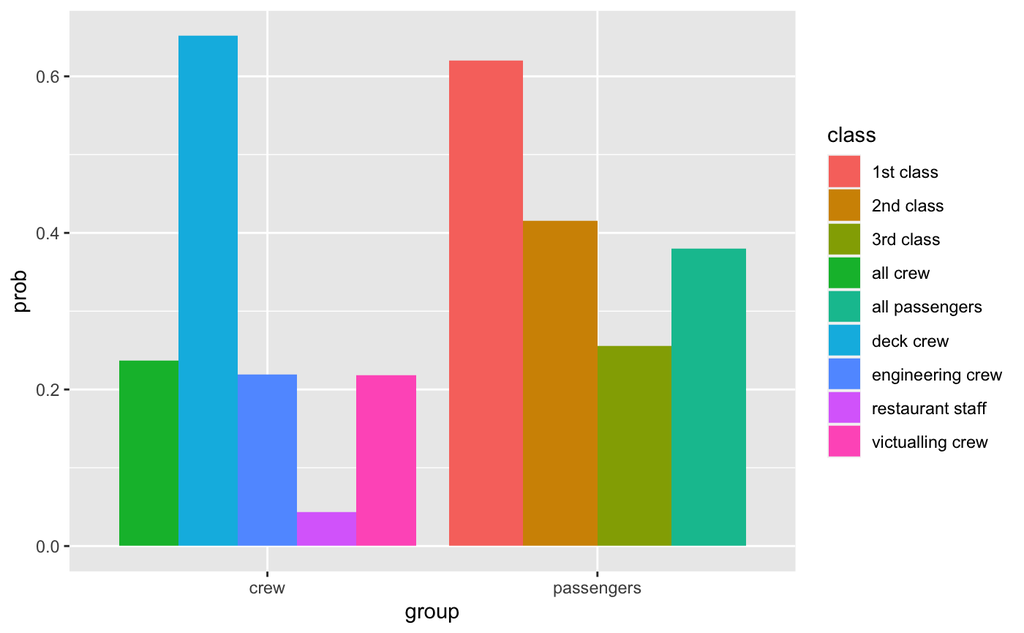

```r
ggplot(prob_survival_by_class, aes(fill=class, y=prob, x=group)) +
    geom_bar(position="dodge", stat="identity")
```